# Text Minning Assignment

Irene Bosque, Mafalda González, Sophie Kersten

2025-04-25

# Introduction

This project explores how the content of English-language song lyrics has evolved from the 1950s to the 2010s, with a particular focus on emotional tone, recurring phrases, and underlying themes. Using a range of text mining techniques, we aim to uncover patterns and shifts in how artists express themselves lyrically. The goal is to see whether the language of popular music has changed, and if so, how.

Our analysis is based on a dataset of song lyrics compiled by Maura et al. (2020), which contains music metadata and lyrics for songs released between 1950 and 2019. The full dataset is openly available at [Mendeley Data](https://data.mendeley.com/datasets/3t9vbwxgr5/3).

We apply multiple main text analysis techniques:

1. **Word frequency analysis:** We start by identifying the most common individual words across decades to understand basic shifts in vocabulary and focus over time.
2. **Sentiment analysis:** We track changes in emotional tone, exploring whether lyrics have become more joyful, sad, angry, or fearful across different periods.
3. **Bigram analysis:** We study recurring two-word combinations (bigrams) to capture more specific expressions, cultural references, and evolving lyrical patterns.
4. **Topic modelling:** We uncover broader thematic structures by grouping words into topics, allowing us to detect deeper and more abstract trends in lyrical content over the decades.

By combining these approaches, the ultimate goal is to combine the insights to tell a data-driven story of musical and cultural evolution, from expressions of love and romance in the 1950s to the rise of emotionally complex anger and sadness, as well socially aware content in more recent years.

## Libraries

To work with this script, the libraries below are requiered. If not dowloaded yet, set the following chunk to eval=T.

```r
# Install packages if needed. This chunk is set to eval=F so that you only have to run these lines once manually.
install.packages("readr")
install.packages("tidyverse")
install.packages("tidytext")
install.packages("topicmodels")
install.packages("tm")
install.packages("quanteda")
install.packages("quanteda.textplots")
install.packages("widyr")
install.packages("wordcloud")
install.packages("reshape2")
install.packages("ggraph")
install.packages("igraph")
install.packages("forcats")
install.packages("ggplot2")
```

Now you can load the libraries as normal:

```r
library(readr)            # reading data
library(tidyverse)        # data wrangling and plotting
library(tidytext)         # text mining
library(topicmodels)      # topic modelling (LDA)
library(tm)               # text mining functions
library(quanteda)         # text analysis (corpus, DFM)
library(quanteda.textplots) # text visualisation
library(widyr)            # pairwise word analysis
library(wordcloud)        # wordclouds
library(reshape2)         # data reshaping
library(ggraph)           # graph plotting
library(igraph)           # network analysis
library(forcats)          # factor management
library(ggplot2)          # plotting
```

Finally, we load the dataset that we will use.

```r
df <- read_csv("tcc_ceds_music.csv")
```

```
## ──────────────────────────────────────────────────────── Delimiter: "," chr
## (5): artist_name, track_name, genre, lyrics, topic dbl (26): ...1,
## release_date, len, dating, violence, world/life, night/time,...
```

# Initial exploration

Before starting any analysis, to make sure that our dataset is clean and valid for text mining tasks and will work with our functions, we have to:

- Preview the data structure
- Check for duplicates
- Identify any missing values

```r
dim(df)
```

```
## [1] 28372    31
```

```r
head(df)
```

```
## # A tibble: 6 × 31
##    ...1 artist_name  track_name release_date genre lyrics   len  dating violence
##   <dbl> <chr>        <chr>             <dbl> <chr> <chr>  <dbl>   <dbl>    <dbl>
## 1     0 mukesh       mohabbat …         1950 pop   hold …    95 5.98e-4  0.0637
## 2     4 frankie lai… i believe          1950 pop   belie…    51 3.55e-2  0.0968
## 3     6 johnnie ray  cry                1950 pop   sweet…    24 2.77e-3  0.00277
## 4    10 pérez prado  patricia           1950 pop   kiss …    54 4.82e-2  0.00155
## 5    12 giorgos pap… apopse ei…         1950 pop   till …    48 1.35e-3  0.00135
## 6    14 perry como   round and…         1950 pop   convo…    98 1.05e-3  0.421
## # ℹ 22 more variables: `world/life` <dbl>, `night/time` <dbl>,
## #   `shake the audience` <dbl>, `family/gospel` <dbl>, romantic <dbl>,
## #   communication <dbl>, obscene <dbl>, music <dbl>, `movement/places` <dbl>,
## #   `light/visual perceptions` <dbl>, `family/spiritual` <dbl>,
## #   `like/girls` <dbl>, sadness <dbl>, feelings <dbl>, danceability <dbl>,
## #   loudness <dbl>, acousticness <dbl>, instrumentalness <dbl>, valence <dbl>,
## #   energy <dbl>, topic <chr>, age <dbl>
```

```r
names(df)
```

```
##  [1] "...1"                     "artist_name"
##  [3] "track_name"               "release_date"
##  [5] "genre"                    "lyrics"
##  [7] "len"                      "dating"
##  [9] "violence"                 "world/life"
## [11] "night/time"               "shake the audience"
## [13] "family/gospel"            "romantic"
## [15] "communication"            "obscene"
## [17] "music"                    "movement/places"
## [19] "light/visual perceptions" "family/spiritual"
## [21] "like/girls"               "sadness"
## [23] "feelings"                 "danceability"
## [25] "loudness"                 "acousticness"
## [27] "instrumentalness"         "valence"
## [29] "energy"                   "topic"
## [31] "age"
```

The dataset we are using has over 28372 entries described with 31 variables, such as `artist_name`, `track_name`, `realease_date` or `genre`. We find our most important column under `lyrics`, as this is the column that will give us our text components to analyse.

```r
df %>%
  duplicated() %>%
  sum()
```

```
## [1] 0
```

```r
df %>%
  summarise_all(~sum(is.na(.)))
```

```
## # A tibble: 1 × 31
##    ...1 artist_name track_name release_date genre lyrics   len dating violence
##   <int>       <int>      <int>        <int> <int>  <int> <int>  <int>    <int>
## 1     0           0          0            0     0      0     0      0        0
## # ℹ 22 more variables: `world/life` <int>, `night/time` <int>,
## #   `shake the audience` <int>, `family/gospel` <int>, romantic <int>,
## #   communication <int>, obscene <int>, music <int>, `movement/places` <int>,
## #   `light/visual perceptions` <int>, `family/spiritual` <int>,
## #   `like/girls` <int>, sadness <int>, feelings <int>, danceability <int>,
## #   loudness <int>, acousticness <int>, instrumentalness <int>, valence <int>,
## #   energy <int>, topic <int>, age <int>
```

We find very no duplicates or missing values, which allows us to proceed without major preprocessing.

## Descriptive analysis

Before diving into text processing, we begin with a basic exploration of the dataset to understand its structure and time coverage.

```r
# Decades with songs
unique(df$release_date)
```

```
##  [1] 1950 1951 1952 1953 1954 1955 1956 1957 1958 1959 1960 1961 1962 1963 1964
## [16] 1965 1966 1967 1968 1969 1970 1971 1972 1973 1974 1975 1976 1977 1978 1979
## [31] 1980 1981 1982 1983 1984 1985 1986 1987 1988 1989 1990 1991 1992 1993 1994
## [46] 1995 1996 1997 1998 1999 2000 2001 2002 2003 2004 2005 2006 2007 2008 2009
## [61] 2010 2011 2012 2013 2014 2015 2016 2017 2018 2019
```

```r
length(unique(df$release_date))
```

```
## [1] 70
```

```r
2019 - 1950
```

```
## [1] 69
```

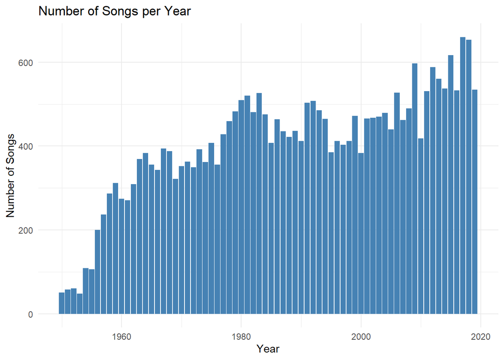

```r
# Number of songs released per year
df %>%
  count(release_date) %>%
  ggplot(aes(x = release_date, y = n)) +
  geom_col(fill = "steelblue") +
  labs(title = "Number of Songs per Year",
       x = "Year", y = "Number of Songs") +
  theme_minimal()
```

The dataset includes songs from 1950 on onwards until 2019, without skipping any year. The number of songs increases significantly starting in the late 1950s, with a steady rise through the 1980s and into the 21st century. The increase is also visible after 2010, possibly reflecting an improved availability of digital music records.

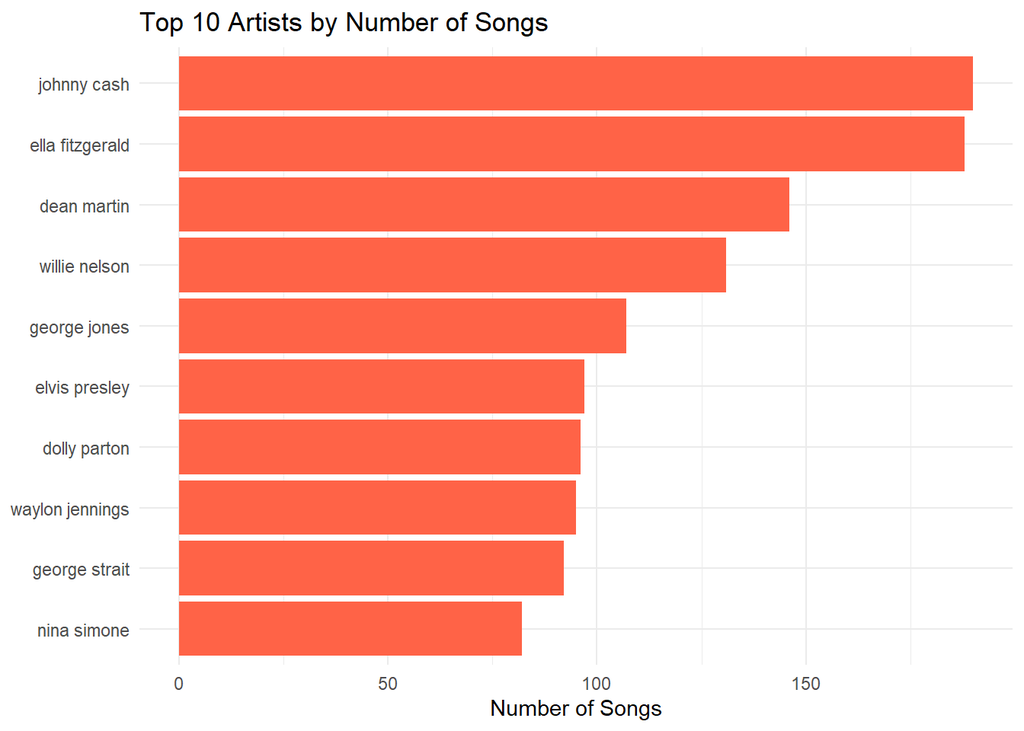

```r
# Top 10 most frequent artists in the dataset
df %>%
  count(artist_name, sort = TRUE) %>%
  top_n(10) %>%
  ggplot(aes(x = reorder(artist_name, n), y = n)) +
  geom_col(fill = "tomato") +
  coord_flip() +
  labs(title = "Top 10 Artists by Number of Songs",
       x = NULL, y = "Number of Songs") +
  theme_minimal()
```

```r
names(df)
```

```
##  [1] "...1"                     "artist_name"
##  [3] "track_name"               "release_date"
##  [5] "genre"                    "lyrics"
##  [7] "len"                      "dating"
##  [9] "violence"                 "world/life"
## [11] "night/time"               "shake the audience"
## [13] "family/gospel"            "romantic"
## [15] "communication"            "obscene"
## [17] "music"                    "movement/places"
## [19] "light/visual perceptions" "family/spiritual"
## [21] "like/girls"               "sadness"
## [23] "feelings"                 "danceability"
## [25] "loudness"                 "acousticness"
## [27] "instrumentalness"         "valence"
## [29] "energy"                   "topic"
## [31] "age"
```

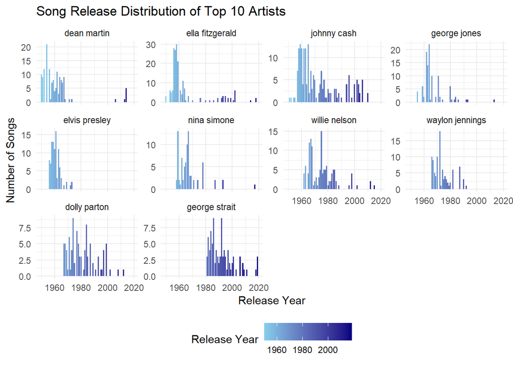

```r
# Get top 10 artists by number of songs
top_artists <- df %>%
  count(artist_name, sort = TRUE) %>%
  top_n(9, n) %>%
  pull(artist_name)

# Filter dataset to include only those top artists
df_top_artists <- df %>%
  filter(artist_name %in% top_artists)

# Identify top 10 artists
top_artists <- df %>%
  count(artist_name, sort = TRUE) %>%
  top_n(10, n) %>%
  pull(artist_name)

# Filter dataset
df_top_artists <- df %>%
  filter(artist_name %in% top_artists)

# Filter and summarise data by year
df_top_artists_years <- df %>%
  filter(artist_name %in% top_artists) %>%
  group_by(artist_name, release_date) %>%
  summarise(songs = n(), .groups = "drop")

# Plot: number of songs per year per artist
ggplot(df_top_artists_years, aes(x = release_date, y = songs, fill = release_date)) +
  geom_col() +
  facet_wrap(~ fct_reorder(artist_name, release_date, .fun = min), scales = "free_y") +
  scale_fill_gradient(low = "skyblue", high = "navy", name = "Release Year") +
  labs(
    title = "Song Release Distribution of Top 10 Artists",
    x = "Release Year",
    y = "Number of Songs"
  ) +
  theme_minimal() +
  theme(legend.position = "bottom")
```

The artists with the most entries are icons like Johnny Cash, Ella Fitzgerald, and Dean Martin. These figures indicate a strong representation of classic country, jazz, and pop artists, likely shaping the lyrical content of earlier decades. There are a few likely reasons why older artists dominate this list. We believe it could be because they have had more time to put songs out. For example, Dolly Parton is still putting music out, yet started in 1967 with her album “Hello, I’m Dolly.” The older artists might have also had higher prolific output, as many classic artists had long productive careers with hundres of songs. In comparison, a raper from the 2010s might just be starting to put as many songs out. And since not all become very famous or repected, they might also not be represented in this list. Hence, we also could be dealing with a certain curation bias for established songs. It is very important to appreciate this potential bias, as it may shape the kinds of themes, emotional tones, and language that dominate the lyrics if we were to analyse them without any further distinction.

## Decade Assignment

To account for these generational imbalances and allow for fairer comparisons, we group the songs by decade, enabling us to analyse trends in lyrics over time while controlling for differences in artist representation and output volume.

```r
# Create decade variable
df <- df %>%
  mutate(decade = floor(release_date / 10) * 10)

# Preview of new column to make sure it works
df %>%
  select(release_date, decade) %>%
  sample_n(5)
```

```
## # A tibble: 5 × 2
##   release_date decade
##          <dbl>  <dbl>
## 1         2017   2010
## 2         1983   1980
## 3         1991   1990
## 4         2016   2010
## 5         2012   2010
```

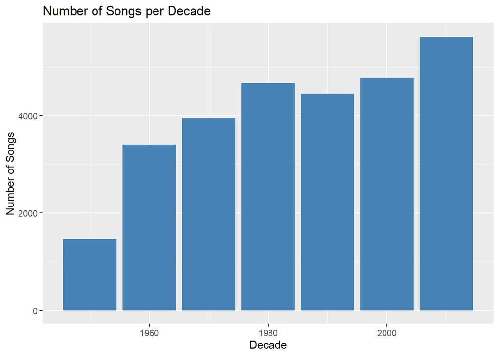

```r
# Number of songs per decade
df %>%
  count(decade) %>%
  ggplot(aes(x = decade, y = n)) +
  geom_col(fill = "steelblue") +
  labs(title = "Number of Songs per Decade",
       x = "Decade",
       y = "Number of Songs")
```

```r
df %>%
  group_by(decade) %>%
  summarize(total = sum(n()))
```

```
## # A tibble: 7 × 2
##   decade total
##    <dbl> <int>
## 1   1950  1468
## 2   1960  3409
## 3   1970  3951
## 4   1980  4675
## 5   1990  4457
## 6   2000  4781
## 7   2010  5631
```

We observe a steady increase in the number of songs across decades, with the 2010s showing the highest volume (5631 songs). This suggests that the dataset is skewed towards more recent decades. As said before, this likely is due to better online availability of moden music. However, while there are more songs are present of recent decades, these could be more distributed across a wider range of artists. This could explain why the Top 10 Artists chart is dominated by older artists from earlier decades, as they may have had more songs included per person; whereas the 2000s and 2010s may contain a broader and more diverse pool of musicians, each with fewer entries on average.

Having understood the structure of our dataset, we now turn to the lyrics themselves. In the next sections, we apply text mining techniques to uncover patterns in language, emotion, and theme over time.

# Word frequency analysis

To begin our text mining exploration, we break the lyrics into individual words (tokens) and remove common stop words like “the”, “and”, or “of” that carry little semantic weight. We do this by using `anti_join` and a specialized list of stopwords, as stopwords can have high and low frequencies, so filtering out frequencies would not work. This allows us to focus on the most meaningful language used across different decades.

```r
lyrics_words <- df %>%
  unnest_tokens(word, lyrics) %>%
  anti_join(stop_words) %>%
  rename(song_id = "...1") # we rename song_id column for clarity
lyrics_words
```

```
## # A tibble: 1,672,703 × 32
##    song_id artist_name track_name      release_date genre   len  dating violence
##      <dbl> <chr>       <chr>                  <dbl> <chr> <dbl>   <dbl>    <dbl>
##  1       0 mukesh      mohabbat bhi j…         1950 pop      95 5.98e-4   0.0637
##  2       0 mukesh      mohabbat bhi j…         1950 pop      95 5.98e-4   0.0637
##  3       0 mukesh      mohabbat bhi j…         1950 pop      95 5.98e-4   0.0637
##  4       0 mukesh      mohabbat bhi j…         1950 pop      95 5.98e-4   0.0637
##  5       0 mukesh      mohabbat bhi j…         1950 pop      95 5.98e-4   0.0637
##  6       0 mukesh      mohabbat bhi j…         1950 pop      95 5.98e-4   0.0637
##  7       0 mukesh      mohabbat bhi j…         1950 pop      95 5.98e-4   0.0637
##  8       0 mukesh      mohabbat bhi j…         1950 pop      95 5.98e-4   0.0637
##  9       0 mukesh      mohabbat bhi j…         1950 pop      95 5.98e-4   0.0637
## 10       0 mukesh      mohabbat bhi j…         1950 pop      95 5.98e-4   0.0637
## # ℹ 1,672,693 more rows
## # ℹ 24 more variables: `world/life` <dbl>, `night/time` <dbl>,
## #   `shake the audience` <dbl>, `family/gospel` <dbl>, romantic <dbl>,
## #   communication <dbl>, obscene <dbl>, music <dbl>, `movement/places` <dbl>,
## #   `light/visual perceptions` <dbl>, `family/spiritual` <dbl>,
## #   `like/girls` <dbl>, sadness <dbl>, feelings <dbl>, danceability <dbl>,
## #   loudness <dbl>, acousticness <dbl>, instrumentalness <dbl>, …
```

A quick look at the first resulting words, such as “time,” “untrue,” or “tear,” shows they are indeed lyrics-related, emotionally loaded, and thematically rich—suggesting that the tokenisation process has worked as expected.

Now, we turn to what these words can tell us: what were the most common words across decades, and how have songs changed in length over time?

## Words over time

We are looking towards insights that reveal how have the words being used have shifted over time and if they reflect content evolution or genre popularity changes. Even though rudimentary, a simple word count can be a great tool to see how the lyrics, and hence, mood of music has changed over time.

The tables below show the most common words by decades and the most common words overall. The plot below shows the ten most frequently used non-stop words in song lyrics across each decade from the 1950s to the 2010s.

```r
most_common_word_by_decade <- lyrics_words %>%
  count(decade, word, sort = TRUE) %>%
  group_by(decade) %>%
  slice_max(n, n = 10)

most_common_word_by_decade
```

```
## # A tibble: 70 × 3
## # Groups:   decade [7]
##    decade word      n
##     <dbl> <chr> <int>
##  1   1950 heart  1078
##  2   1950 time    932
##  3   1950 blue    654
##  4   1950 baby    601
##  5   1950 leave   541
##  6   1950 dream   515
##  7   1950 night   509
##  8   1950 kiss    460
##  9   1950 hear    452
## 10   1950 feel    451
## # ℹ 60 more rows
```

```r
most_common_word_by_decade %>%
  ungroup() %>%
  select(-decade) %>%
  group_by(word) %>%
  summarise(total_n = sum(n)) %>%
  arrange(desc(total_n))
```

```
## # A tibble: 18 × 2
##    word  total_n
##    <chr>   <int>
##  1 time    26504
##  2 feel    16795
##  3 heart   16737
##  4 yeah    16531
##  5 life    15478
##  6 baby    13707
##  7 leave   12790
##  8 live    12513
##  9 night    7848
## 10 world    5066
## 11 wanna    2866
## 12 fuck     2654
## 13 gonna    2001
## 14 break    1905
## 15 dream    1736
## 16 blue      654
## 17 kiss      460
## 18 hear      452
```

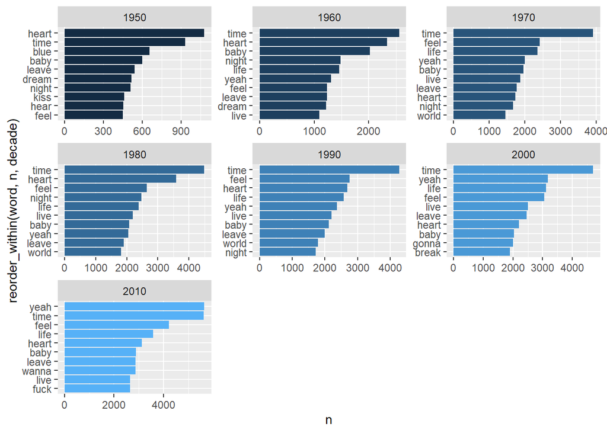

```r
# Plot
most_common_word_by_decade %>%
  ggplot(aes(reorder_within(word, n, decade), n, fill = decade)) +
  geom_col(show.legend = FALSE) +
  facet_wrap(~decade, scales = "free") +
  scale_x_reordered() +
  coord_flip()
```

In the plot we can see that some words appear consistently in the top 10 across all or nearly all decades. “Time” is present in all seven decades, and the most frequent word overall with 26504 appearances. Its consistent presence suggests an enduring focus on temporality concepts that could be memories, moments, urgency, or have a philosophical reflection. In any case, “time” is highly important. The next 7 most frequent words round between the 16700 and 12500 appearences, and include “**feel**,” “**heart**,” “**yeah**,” “**life**,” “**baby**,” “**leave**,” and “**live**.” These words suggest that emotion (“feel,” “heart”), relationships (“baby,” “leave”), and experiences (“live,” “life”) are timeless themes in music, though the context in which they are used may evolve.

All in all we can say that these patterns reflect both musical genre shifts and changing social and cultural norms. The lyrical focus of songs has expanded and modernised over time. As the early decades (1950s–1970s) are steeped in romantic and emotional vocabulary, we see that starting in the 1980s and especially in the 2000s and 2010s, we see more casual, assertive, and even explicit language emerging, reflecting broader cultural changes around self-expression, social norms, and genre evolution. Finally, the consistency of emotional words like “heart,” “feel,” and “baby” shows that, despite these shifts, music has always remained a vehicle for emotional storytelling.

Having seen now the emotional side of word frequency analysis, we explore now a more technical question: are songs getting longer or shorter?

## Structural decomposition of songs

In the table we can have the evolution of song length since the 1950s, which we have visualised in the graph.

```r
lyrics_stats <- lyrics_words %>%
  group_by(song_id, decade) %>%
  summarise(total_words = n()) %>%
  group_by(decade) %>%
  summarise(mean_length = mean(total_words))
lyrics_stats
```

```
## # A tibble: 7 × 2
##   decade mean_length
##    <dbl>       <dbl>
## 1   1950        44.7
## 2   1960        44.6
## 3   1970        51.6
## 4   1980        57.3
## 5   1990        61.5
## 6   2000        64.2
## 7   2010        71.5
```

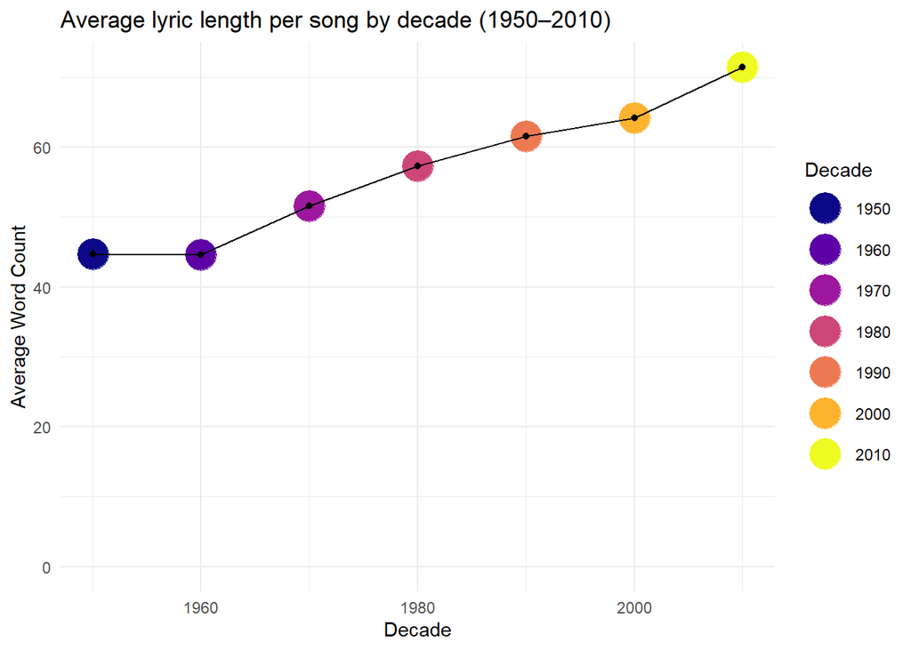

```r
# Plot
ggplot(lyrics_stats, aes(x = decade, y = mean_length)) +
  geom_point(aes(colour = as.factor(decade)), size = 8) +
  scale_colour_viridis_d(name = "Decade", option = "C") +
  scale_y_continuous(limits = c(0, NA)) +
  geom_line() +
  geom_point() +
  labs(
    title = "Average lyric length per song by decade (1950–2010)",
    x = "Decade",
    y = "Average Word Count"
    ) +
  theme_minimal()
```

We can see that lyric length remained relatively stable in the 1950s and 1960s, but then began a steady rise from the 1970s onward. By the 2010s, the average song had over 70 words, roughly 60% more than in the 1950s.

This upwards trend may reflect a move toward more lyrically dense genres like rap and indie pop, changes in song structure, with more verses and fewer instrumental breaks, or maybe a change in production norms allowing for longer tracks.

However, while lyrics have become longer over time, this does not necessarily mean they’ve become more complex: using more words does not always mean saying more. It could simply reflect a shift in lyrical style or vocabulary.

While word frequency tells us what kinds of words dominate lyrics, it doesn’t reveal the emotional tone behind them. To better understand what is being expressed, rather than just how much, we now turn to sentiment analysis to explore the emotional tone of songs across decades.

# Sentiment Analysis

Sentiment Analysis is a great tool to quantify the emotions being expressed in our lyrics.

## Net sentiment score per decade

```r
sentiment_by_decade <- lyrics_words %>%
  inner_join(get_sentiments("bing")) %>%
  group_by(decade, sentiment) %>%
  count() %>%
  pivot_wider(names_from = sentiment, values_from = n, values_fill = 0) %>%
  mutate(sentiment_score = positive - negative)
```

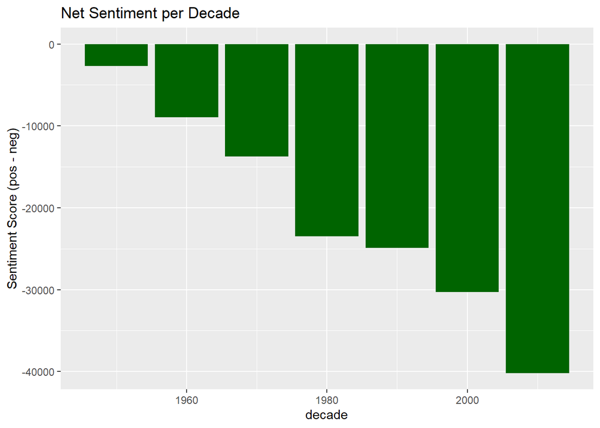

```r
ggplot(sentiment_by_decade, aes(x = decade, y = sentiment_score)) +
  geom_col(fill = "darkgreen") +
  labs(title = "Net Sentiment per Decade",
       y = "Sentiment Score (pos - neg)")
```

This plot shows the net sentiment score per decade, calculated as the difference between positive and negative word occurrences using Bing sentiment lexicon. A clear downward trend is visible: while lyrics in the 1950s and 1960s maintained a relatively balanced emotional tone, the net sentiment becomes increasingly negative from the 1970s onward.

This could reflect broader cultural shifts: lyrics may have become more emotionally complex, critical, or raw over time, especially with the rise of genres like hip hop, grunge, and trap, which often focus on social struggles, existential topics, and direct emotional expression.

## Emotions in lyrics across time

Firstly, we use the NRC lexicon, which classifies words into categories like **joy**, **sadness**, **anger**, **trust**, and **fear**. By mapping each word in the lyrics to these emotional labels, we can track how the emotional landscape of music has changed over time.

```r
# sentiment attribution
nrc_emotions <- lyrics_words %>%
  inner_join(get_sentiments("nrc")) %>%
  count(decade, sentiment) %>%
  filter(sentiment %in% c("anger", "joy", "fear", "trust", "sadness"))
nrc_emotions
```

```
## # A tibble: 35 × 3
##    decade sentiment     n
##     <dbl> <chr>     <int>
##  1   1950 anger      3346
##  2   1950 fear       4189
##  3   1950 joy        7021
##  4   1950 sadness    5892
##  5   1950 trust      6149
##  6   1960 anger      9105
##  7   1960 fear      11014
##  8   1960 joy       14751
##  9   1960 sadness   14029
## 10   1960 trust     12780
## # ℹ 25 more rows
```

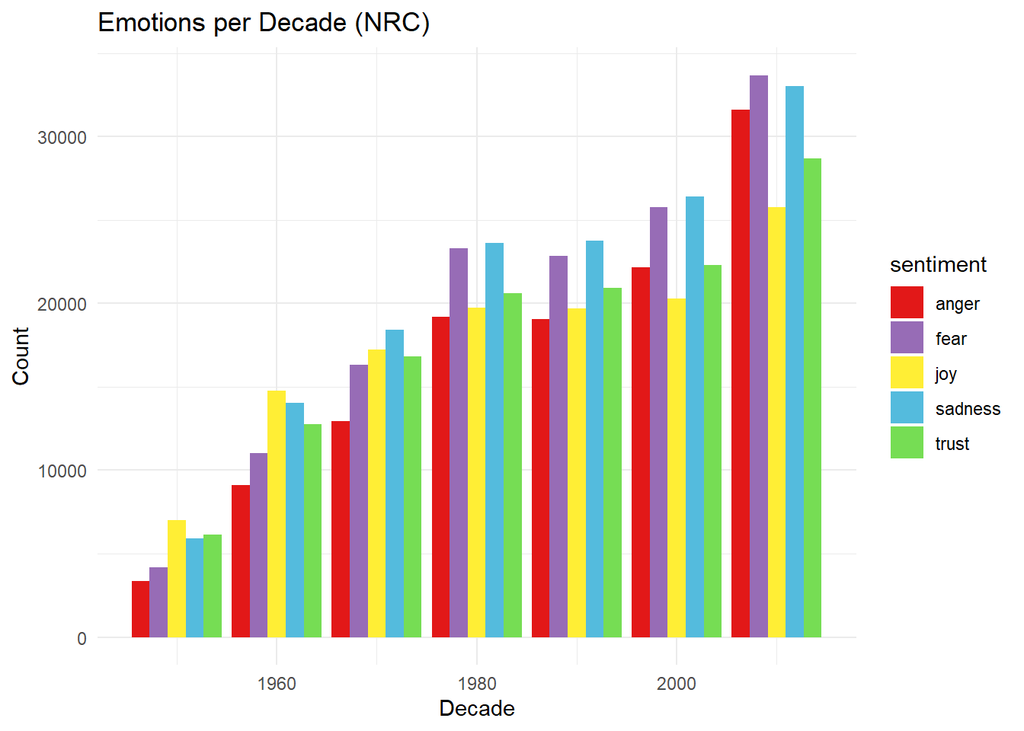

```r
# Plot
ggplot(nrc_emotions, aes(x = decade, y = n, fill = sentiment)) +
  geom_col(position = "dodge") +
  scale_fill_manual(values = c(
  "anger" = "#e21818",
  "fear" = "#976cb6",
  "sadness" = "#54bbdd",
  "joy" = "#ffee35",
  "trust" = "#76dd54"
)) +
  labs(title = "Emotions per Decade (NRC)",
       y = "Count",
       x = "Decade") +
  theme_minimal()
```

This plot shows the count of emotion-related words found in lyrics across each decade (1950–2010) using the NRC sentiment lexicon. As expected, the total number of emotion-related words increases steadily over the decades, which reflects the growing number of songs in the dataset and the longer lyrics by song in recent decades. With this plot we can analyse the relative prominence and pace of change between emotions.

Interestingly, while the count of words associated with **joy** also increases, its growth is more modest in comparison. By the 2010s, joy appears to be outpaced by sadness, fear, and even trust. This could indicate a relative decline in cheerful or celebratory themes in mainstream music, possibly due to the rise of genres like hip hop, alternative rock, and indie pop that tend to focus more on personal struggle, identity, and existential topics.

However, if we actually want to analyse the emotions by decade independently of the selection bias of our dataset, we have to take a different approach. A more robust tactic is to calculate the mean number of emotion-related words per song within each decade. With this we help control for selection bias and can more reliably make cross-decade comparisons. The goal is to shift the focus from overall volume to lyrical density: how emotionally expressive the average song is in each decade, independent of how many songs were written.

```r
# sentiment attribution
nrc_emotions <- lyrics_words %>%
  inner_join(get_sentiments("nrc")) %>%
  count(decade, sentiment)
# number of songs per decade
songs_per_decade <- df %>%
  group_by(decade) %>%
  summarise(song_count = n())

# join + mean per song
nrc_emotions_normalised <- nrc_emotions %>%
  left_join(songs_per_decade, by = "decade") %>%
  mutate(mean_per_song = n / song_count) %>%
  filter(sentiment %in% c("anger", "joy", "fear", "trust", "sadness"))
nrc_emotions_normalised
```

```
## # A tibble: 35 × 5
##    decade sentiment     n song_count mean_per_song
##     <dbl> <chr>     <int>      <int>         <dbl>
##  1   1950 anger      3346       1468          2.28
##  2   1950 fear       4189       1468          2.85
##  3   1950 joy        7021       1468          4.78
##  4   1950 sadness    5892       1468          4.01
##  5   1950 trust      6149       1468          4.19
##  6   1960 anger      9105       3409          2.67
##  7   1960 fear      11014       3409          3.23
##  8   1960 joy       14751       3409          4.33
##  9   1960 sadness   14029       3409          4.12
## 10   1960 trust     12780       3409          3.75
## # ℹ 25 more rows
```

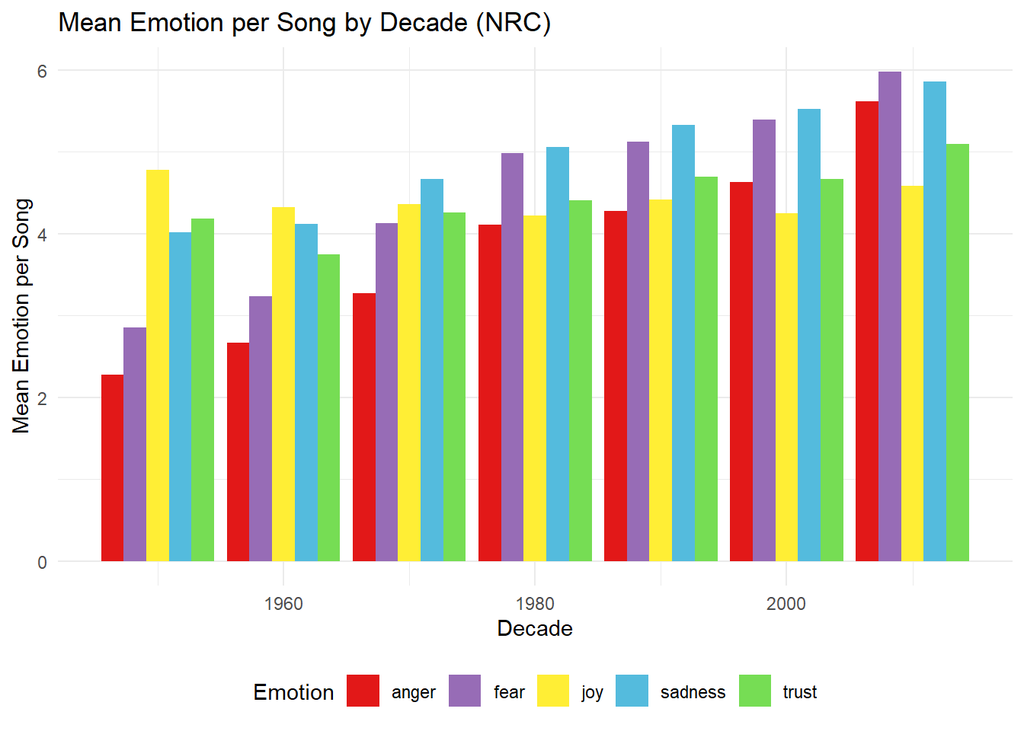

```r
# Plot
ggplot(nrc_emotions_normalised, aes(x = decade, y = mean_per_song, fill = sentiment)) +
  geom_col(position = "dodge") +
  scale_fill_manual(values = c(
    "anger" = "#e21818",
    "fear" = "#976cb6",
    "sadness" = "#54bbdd",
    "joy" = "#ffee35",
    "trust" = "#76dd54"
  )) +
  labs(
    title = "Mean Emotion per Song by Decade (NRC)",
    y = "Mean Emotion per Song",
    x = "Decade",
    fill = "Emotion"
  ) +
  theme_minimal() +
  theme(legend.position = "bottom")
```

By normalising the number of emotion-related words per song, we avoid bias from having more songs in recent decades. The data reveal a more moderate shift in emotional expression over time.

Although **joy** remains relatively stable across decades, it follows a very different patterns than the other emotions, as it decreases from the 1950s to the 1960s, and then mantains a steady course onward. This implies that while positive sentiment continues to exist in the lyrics, it is increasingly balanced or even overshadowed by more complex and emotionally intense language.

Due to the prominent rising of the anger emotion, we take a look at its expression over the decades.

```r
# sentiment selection
nrc_anger <- get_sentiments("nrc") %>%
  filter(sentiment == "anger")

# sentiment extraction by decade
anger_words_by_decade <- lyrics_words %>%
  inner_join(nrc_anger, by = "word") %>%
  count(decade, word, sort = TRUE)

# grouping by decade for table
top_anger_words_by_decade <- anger_words_by_decade %>%
  group_by(decade) %>%
  slice_max(order_by = n, n = 10) %>%
  arrange(decade, desc(n)) %>%
  ungroup()

top_anger_words_by_decade
```

```
## # A tibble: 71 × 3
##    decade word       n
##     <dbl> <chr>  <int>
##  1   1950 lose     222
##  2   1950 lonely   220
##  3   1950 money    170
##  4   1950 shit      97
##  5   1950 devil     94
##  6   1950 bout      79
##  7   1950 tree      72
##  8   1950 fight     70
##  9   1950 hurt      69
## 10   1950 bitch     68
## # ℹ 61 more rows
```

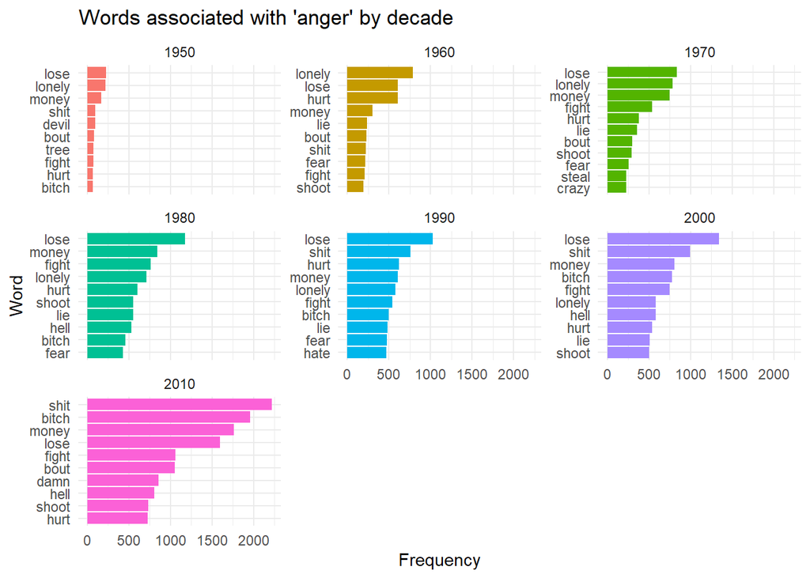

```r
# plot
anger_words_by_decade %>%
  group_by(decade) %>%
  top_n(10, n) %>%
  ungroup() %>%
  ggplot(aes(x = reorder_within(word, n, decade), y = n, fill = factor(decade))) +
  geom_col(show.legend = FALSE) +
  facet_wrap(~ decade, scales = "free_y") +
  scale_x_reordered() +
  coord_flip() +
  labs(title = "Words associated with 'anger' by decade",
     x = "Word",
     y = "Frequency") +
  theme_minimal()
```

The most common anger-related words in earlier decades, like “**lose**,” “**lonely**,” and “**hurt**,” reflect a more emotional and personal tone. By the 1970s and 80s, words such as “**fight**,” “**shoot**,” and “**hell**” become more frequent, signalling a shift toward more confrontational expressions of anger. In the 1990s and especially the 2010s, explicit terms like “**shit**,” “**bitch**,” and “**damn**” rise sharply, reflecting the influence of hip-hop and a broader acceptance of raw, unfiltered language in music. This evolution points to a shift from internalised frustration to more direct, aggressive expressions of external anger in modern lyrics.

Let us see how these anger, as well as the other emotions, change in frequency over decades.

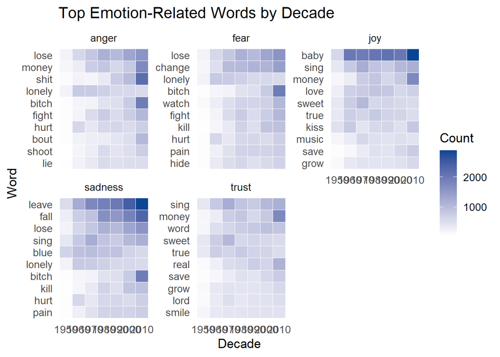

```r
# FIND EMOTIONS ---------------------------
# joy -------------------------------------
# sentiment selection
nrc_joy <- get_sentiments("nrc") %>%
  filter(sentiment == "joy")

# sentiment extraction by decade
joy_words_by_decade <- lyrics_words %>%
  inner_join(nrc_joy, by = "word") %>%
  count(decade, word, sort = TRUE)

# sentiment extraction (independent of decade)
top_joy_words <- lyrics_words %>%
  inner_join(nrc_joy, by = "word") %>%
  count(word, sort = TRUE) %>%
  slice_max(order_by = n, n = 10)

# anger -----------------------------------
# previous steps already done in chunk before
top_anger_words <- lyrics_words %>%
  inner_join(nrc_anger, by = "word") %>%
  count(word, sort = TRUE) %>%
  slice_max(order_by = n, n = 10)

# sadness ----------------------------------
nrc_sadness <- get_sentiments("nrc") %>%
  filter(sentiment == "sadness")

sadness_words_by_decade <- lyrics_words %>%
  inner_join(nrc_sadness, by = "word") %>%
  count(decade, word, sort = TRUE)

top_sadness_words <- lyrics_words %>%
  inner_join(nrc_sadness, by = "word") %>%
  count(word, sort = TRUE) %>%
  slice_max(order_by = n, n = 10)

# fear --------------------------------------
nrc_fear <- get_sentiments("nrc") %>%
  filter(sentiment == "fear")

fear_words_by_decade <- lyrics_words %>%
  inner_join(nrc_fear, by = "word") %>%
  count(decade, word, sort = TRUE)

top_fear_words <- lyrics_words %>%
  inner_join(nrc_fear, by = "word") %>%
  count(word, sort = TRUE) %>%
  slice_max(order_by = n, n = 10)

# trust -------------------------------------
nrc_trust <- get_sentiments("nrc") %>%
  filter(sentiment == "trust")

trust_words_by_decade <- lyrics_words %>%
  inner_join(nrc_trust, by = "word") %>%
  count(decade, word, sort = TRUE)

top_trust_words <- lyrics_words %>%
  inner_join(nrc_trust, by = "word") %>%
  count(word, sort = TRUE) %>%
  slice_max(order_by = n, n = 10)

# PLOT ---------------------------------------
# bind top words for all five emotions
top_emotion_words <- bind_rows(
  top_joy_words %>% mutate(sentiment = "joy"),
  top_sadness_words %>% mutate(sentiment = "sadness"),
  top_anger_words %>% mutate(sentiment = "anger"),
  top_fear_words %>% mutate(sentiment = "fear"),
  top_trust_words %>% mutate(sentiment = "trust")
)

# filter for top emotions
top_emotion_counts <- lyrics_words %>%
  semi_join(top_emotion_words, by = "word") %>%
  count(decade, word) %>%
  # add sentiment labels
  left_join(
    top_emotion_words %>% select(word, sentiment),
    by = "word")
# top_emotion_counts # table

# heatmap
ggplot(top_emotion_counts, aes(x = factor(decade), y = reorder(word, n), fill = n)) +
  geom_tile(colour = "white") +
  facet_wrap(~ sentiment, scales = "free_y") +
  scale_fill_gradient(low = "white", high = "#084594") +
  labs(
    title = "Top Emotion-Related Words by Decade",
    x = "Decade",
    y = "Word",
    fill = "Count"
  ) +
  theme_minimal(base_size = 13) +
  theme(panel.grid = element_blank())
```

Taking a look at the heatmap of the most frequent emotionally charged words over time reveals both continuity and change in lyrical expression.

Words like “**baby**,” “**sweet**,” and “**sing**” (associated with **joy** and **trust**) appear consistently in every decade, pointing to a lasting emotional core in popular music centred around love, tenderness, and musicality.

A couple words like “**lonely**” and “**blue**” under **sadness** show a decreasing trend, in favour of words like “**leave**” and “**lose**,” highlighting the enduring nature of heartbreak and isolation as lyrical themes.

On the other hand, terms like “**bitch**,” “**shit**,” and “**kill**,” linked to **anger**, **sadness**, and **fear**, have surged dramatically in recent decades, especially from the 1990s onward. Confirming our previous word count analysis, their rise reflects a shift toward more explicit, raw, and confrontational language.

## Positive and negative sentiment over time

After examining individual emotions and specific words, we now turn to a broader comparison of general sentiment: how the balance between positive and negative language in lyrics has changed over time.

```r
# ratio calculation
bing_ratio <- lyrics_words %>%
  inner_join(get_sentiments("bing")) %>%
  count(decade, sentiment) %>%
  pivot_wider(names_from = sentiment, values_from = n, values_fill = 1) %>%
  mutate(ratio = positive / negative)
# table
bing_ratio
```

```
## # A tibble: 7 × 4
##   decade negative positive ratio
##    <dbl>    <int>    <int> <dbl>
## 1   1950     7916     5250 0.663
## 2   1960    19466    10500 0.539
## 3   1970    26938    13171 0.489
## 4   1980    39311    15836 0.403
## 5   1990    41299    16391 0.397
## 6   2000    47138    16865 0.358
## 7   2010    61417    21236 0.346
```

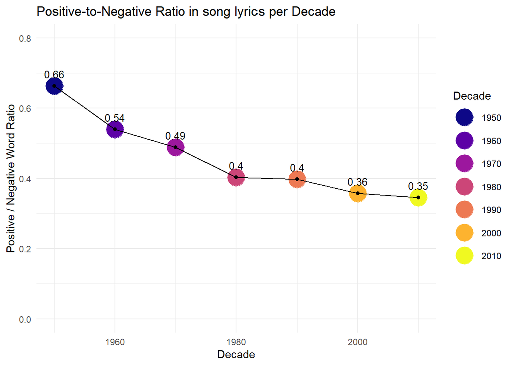

```r
# Plot
ggplot(bing_ratio, aes(x = decade, y = ratio)) +
  geom_point(aes(colour = as.factor(decade)), size = 8) +
  scale_colour_viridis_d(name = "Decade", option = "C") +
  scale_y_continuous(limits = c(0, 0.80)) +
   geom_text(aes(label = round(ratio, 2)), vjust = -1, size = 3.5, colour = "black") +
  geom_line() +
  geom_point() +
  labs(title = "Positive-to-Negative Ratio in song lyrics per Decade",
       x = "Decade",
       y = "Positive / Negative Word Ratio") +
  theme_minimal()
```

The graph shows a clear and continuous decline in the ratio of positive to negative words from the 1950s to the 2010s. In the 1950s, there were approximately **66 positive** words for every **100 negative words**, but by the 2010s, this had dropped to just **35 positive** words per **100 negatives**. This shift suggests that lyrics have become increasingly dominated by **negative** sentiment over the past 70 years, reinforcing our previous findings about the growing prevalence of sadness, fear, and anger.

Modern songs not only use more emotionally charged language, but they also skew more negative in tone. The consistent drop across each decade suggests this is not due to fluctuations in genre or artist popularity but it actually reflects a deeper, long-term shift in how artists express themselves. Lyrics today are not only longer and richer in vocabulary and emotion, but also more likely to focus on negative emotions than they were in previous generations.

Lets visualise this trend with some wordclouds.

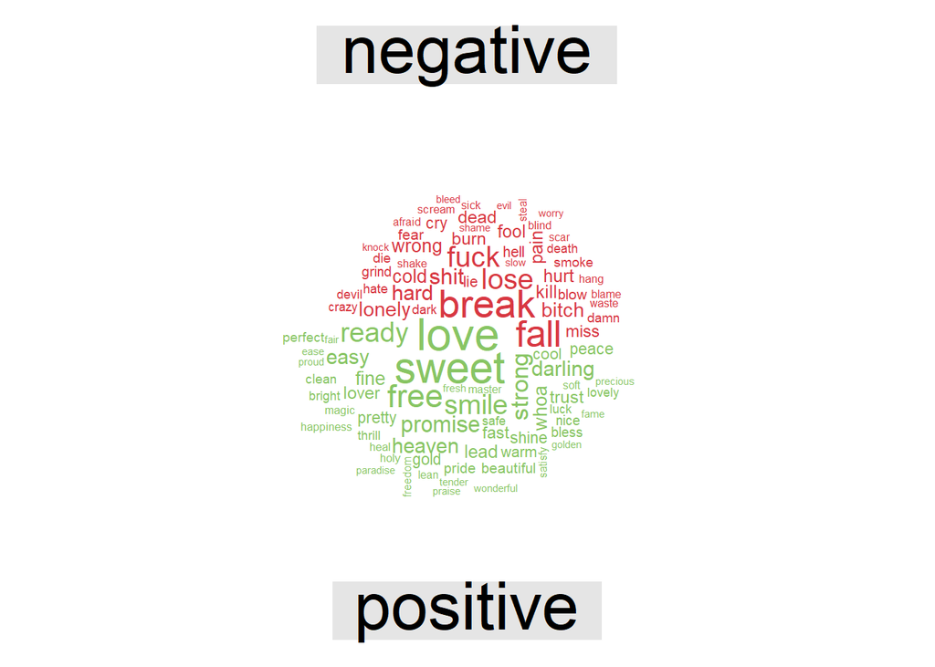

```r
library(wordcloud)
library(reshape2)

#general
set.seed(123)

# with tidy ------------------------------------------
lyrics_words %>%
  inner_join(get_sentiments("bing"), by = "word") %>%
  count(word, sentiment, sort = TRUE) %>%
  acast(word ~ sentiment, value.var = "n", fill = 0) %>%
  comparison.cloud(
    colors = c("#D83842", "#88C564"),
    max.words = 100,
    scale = c(2, 0.3),
    random.order = FALSE
    )
```

[figure not shown]

```r
library(quanteda)
library(quanteda.textplots)

# with DFM --------------------------------------------
# extract sentiments
sentiment_words <- lyrics_words %>%
  inner_join(get_sentiments("bing")) %>%
  count(word, sentiment, sort = TRUE)
# DFM with counts only once per word, not per decade
dfm_sent <- sentiment_words %>%
  mutate(doc = "all_lyrics") %>%
  cast_dfm(doc, word, n)

# match colours to sentiment
word_sentiments <- sentiment_words %>%
  distinct(word, sentiment)

word_colors <- ifelse(word_sentiments$sentiment == "positive", "#88C564", "#D83842")

textplot_wordcloud(dfm_sent,
                   min_count = 5,
                   random_order = FALSE,
                   rotation = .25,
                   color = word_colors)
```

The wordcloud visualises the most frequent positive and negative words found in the lyrics, based on the Bing sentiment lexicon.

We see that negative words such as “**break**,” “**fall**,” “**lose**,” “**shit**,” “**fuck**,” and “**bitch**” appear prominently for the negative words, reflecting the strong presence of emotional conflict, struggle, and explicit language in modern music. Positive terms are exemplified by “**sweet**,” “**love**,” “**free**,” and “**ready**”. However, only “**love**” and “**sweet**” are of considerable size, while the other positive words seem to be generally rather smaller, signifying their less frequent appearances. This echoes what we observed in the positive-to-negative ratio plot.

## Conclusion

Overall, sentiment analysis reveals a clear emotional evolution in lyrics across the decades, with a growing presence of negative sentiment and emotionally intense language in more recent songs, suggesting that contemporary music is increasingly used as a space for expressing inner struggles, social tension, and complex emotions.

Having explored the emotional tone of lyrics thorugh sentiment analysis, we take our analysis now one step further to look at patterns in word pairings.

# N-GRAMS

N-grams allow us to examine not just individual word frequencies, but also how words are used together. To goal is to uncover recurring phrases, expressions, and linguistic patterns in lyrics, revealing themes, styles, and relationships between concepts.

We choose to analyse bi-grams, as they can reflect idiomatic phrases, emotional expressions, or genre-specific language patterns. With count we can examine the most frequent bi-grams.

```r
songs_bigrams <- df %>%
  unnest_tokens(bigram, lyrics, token = "ngrams", n = 2) %>%
  filter(!is.na(bigram))

songs_bigrams %>%
  select(bigram, decade) %>%
  sample_n(5)
```

```
## # A tibble: 5 × 2
##   bigram                decade
##   <chr>                  <dbl>
## 1 heartaches heartaches   1980
## 2 forget sour             2000
## 3 nightmares dream        1960
## 4 blade cagily            1960
## 5 charm want              1950
```

```r
songs_bigrams %>%
  count(bigram, sort = TRUE)
```

```
## # A tibble: 764,056 × 2
##    bigram               n
##    <chr>            <int>
##  1 yeah yeah         2865
##  2 time time         2207
##  3 feel like         2011
##  4 know know         1857
##  5 break heart       1811
##  6 go go             1769
##  7 away away         1525
##  8 lyric commercial  1423
##  9 hold hold         1353
## 10 long long         1332
## # ℹ 764,046 more rows
```

Because many of the most frequent bigrams consist of common stopwords, we proceed to clean the bigram data by removing stopwords from both word positions and also create a dataset that counts the bigrams by decade.

```r
bigrams_separated <- songs_bigrams %>%
  separate(bigram, c("word1", "word2"), sep = " ")

bigrams_filtered <- bigrams_separated %>%
  filter(!word1 %in% stop_words$word) %>%
  filter(!word2 %in% stop_words$word)

bigrams_united <- bigrams_filtered %>%
  unite(bigram, word1, word2, sep = " ")

bigram_counts_decade <- bigrams_united %>%
  count(decade, bigram, sort = TRUE)
```

Having prepared our various bigrams datasets, we can now do some analysis.

## Follow up words to Love and Hate

W want to explore conditional n-grams, i.e. how the second word in a phrase depends on the first to better understand how certain emotionally charged words are used in context.

Let’s see what is the most repeated word after love in these songs through the decades:

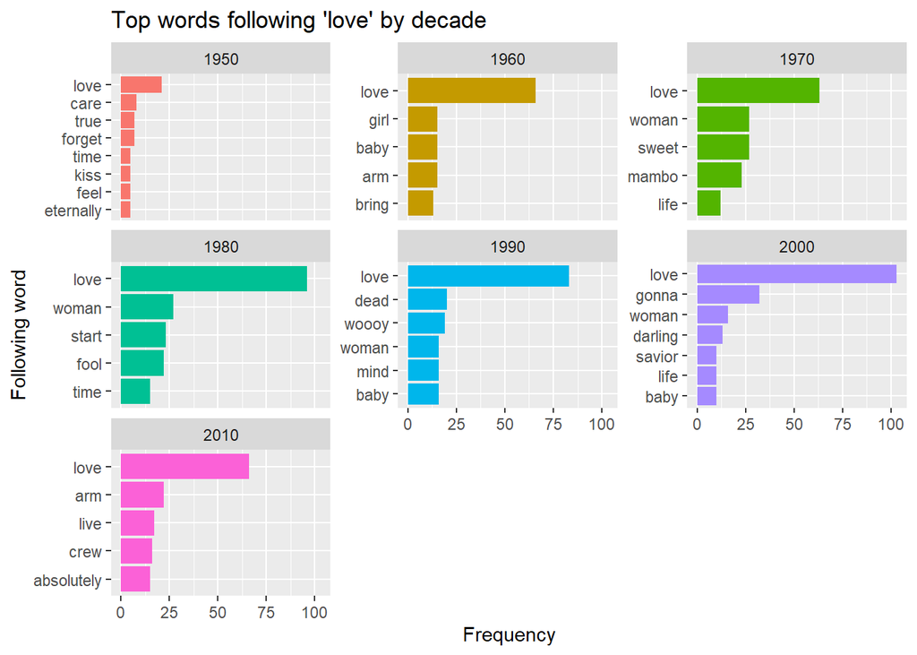

```r
love_bigrams <- bigrams_filtered %>%
  filter(word1 == "love") %>%
  count(decade, word1, word2, sort = TRUE)

# love_bigrams

bigrams_filtered %>%
  filter(word1 == "love") %>%
  count(decade, word2, sort = TRUE) %>%
  group_by(decade) %>%
  slice_max(order_by = n, n = 5) %>%
  ggplot(aes(x = reorder_within(word2, n, decade), y = n, fill = factor(decade))) +
  geom_col(show.legend = FALSE) +
  facet_wrap(~decade, scales = "free_y") +
  scale_x_reordered() +
  coord_flip() +
  labs(
    title = "Top words following 'love' by decade",
    x = "Following word",
    y = "Frequency"
  )
```

In all decades, the most popular word after “**love**” is “**love**.” This might be explained by pop music and chorus with repetitive lyrics, e.g. “love, love, love.”

Using quanteda, we can take a quick look at the context of the word love.[^3]

```r
library(quanteda)

lyrics_corpus <- corpus(df$lyrics, docvars = data.frame(label = df$decade))

kwic(tokens(lyrics_corpus), "love", window = 5)
```

```
## Keyword-in-context with 4,765 matches.
##     [text38, 43]               headphones tomorrow plan shop spree | love |
##     [text40, 42]                time year mistletoeing hearts glow | love |
##     [text40, 68]                time year mistletoeing hearts glow | love |
##      [text48, 6]                       bell stmary hear call young | love |
##      [text48, 8]                         hear call young love true | love |
##     [text48, 22]                       bell stmary hear call young | love |
##     [text48, 24]                         hear call young love true | love |
##     [text55, 42]                     heart beat cage friends laugh | love |
##     [text57, 22]                      hearted heart know pain hadn | love |
##     [text74, 12]                       dream come true girls world | love |
##     [text88, 18]                    tell know goodbye know pretend | love |
##     [text88, 28]                    tell know goodbye know pretend | love |
##     [text91, 24]                      deep inside feel feel divine | love |
##     [text91, 38]                      deep inside feel feel divine | love |
##    [text115, 29]                     young need somethin hold give | love |
##    [text127, 51]                        arm arm arm surrender girl | love |
##   [text147, 140]                      need make life complete know | love |
##   [text159, 120]                         blue like rent cream like | love |
##     [text165, 2]                                             years | love |
##    [text165, 12]                   inside heart smile tear darling | love |
##    [text165, 27]                    appear brush away tear darling | love |
##    [text165, 37]                      time heart long near darling | love |
##    [text165, 53]                     dear lips banish fear darling | love |
##    [text168, 14]                        wild wanna line yeah wanna | love |
##    [text178, 13]                       rain long tell true twelfth | love |
##     [text179, 7]                share lonely hours moments despair | love |
##     [text179, 8]                 lonely hours moments despair love | love |
##    [text179, 10]                    moments despair love love feel | love |
##    [text179, 15]                         love kiss miss away today | love |
##    [text179, 17]                         miss away today love feel | love |
##    [text179, 25]                       wish fame truly truly truly | love |
##    [text179, 31]                       things kiss miss away today | love |
##    [text179, 33]                         miss away today love feel | love |
##    [text179, 34]                         away today love feel love | love |
##    [text179, 35]                         today love feel love love | love |
##    [text179, 37]                          feel love love love feel | love |
##    [text189, 29]                        ohoh heart tear apart hold | love |
##    [text198, 16]                       away voice speak tear bedim | love |
##    [text221, 14]                      apart near heart moment hour | love |
```

[output cut: 1948 more lines]

```
##  speak different voice think tell
##  speak different voice things know
##  speak different voice think speak
##  speak different voice speak different
##  tear tear yeah cause wanna
##  things die night today make
##  shake bouncin tippin glass normally
##  love beneath sheet paper lie
##  beneath sheet paper lie truth
##  control demi lovato heart attack
##  like winter head water pour
##  baby change wildin like dont
##  teach trust dont know know
##  tonight stop endless fight maybe
## [ reached max_nrow ... 3,765 more matches ]
```

```r
df %>%
  slice(666)
```

```
## # A tibble: 1 × 32
##    ...1 artist_name   track_name release_date genre lyrics   len dating violence
##   <dbl> <chr>         <chr>             <dbl> <chr> <chr>  <dbl>  <dbl>    <dbl>
## 1  1767 the impressi… i'm the o…         1963 pop   love …    59 0.0576 0.000975
## # ℹ 23 more variables: `world/life` <dbl>, `night/time` <dbl>,
## #   `shake the audience` <dbl>, `family/gospel` <dbl>, romantic <dbl>,
## #   communication <dbl>, obscene <dbl>, music <dbl>, `movement/places` <dbl>,
## #   `light/visual perceptions` <dbl>, `family/spiritual` <dbl>,
## #   `like/girls` <dbl>, sadness <dbl>, feelings <dbl>, danceability <dbl>,
## #   loudness <dbl>, acousticness <dbl>, instrumentalness <dbl>, valence <dbl>,
## #   energy <dbl>, topic <chr>, age <dbl>, decade <dbl>
```

For example, on page 11 for the line of
$$text666, 41$$
we see that the 10 words in which “**love**” sits between are “**heart want love love love**” and “**look eye time realize love**.” Taking a look at the specific song we see that it is a 1963 song called “I’m the one who loves you” by “The Impressions,” and the specific sentences goes like this:

“Also confess what my **heart** **wants** me to  
That I’m the one who **loves** you  
I’m the one who **loves** you  
A **love** me  
I’m the one who **loves** you  
Yes, once more you’ll **look** in my **eyes**  
And one more **time** you won’t **realize**  
That I’m the one who **loves** you”[^4]

This is a great example to see how the word “**love**” becomes so overly when conditioned by the previous word “**love**.” Through the work of filtering stopwords we see how actually there is quite a lot of context between each love, but yet the stopword filtering reveals the central and undisputable topic of the lyrics: lots of love.

Other interesting words after “**love**” are “**eternally**” (1950s), “**girl**” (1960s), “**mambo**” (1970s), “**fool**” (1980s), “**dead**” and “**woooy**” (1990s), “**savior**” (2000s), “**arm**” and “**crew**” (2010s).

Let’s look now at words after “**hate**.”

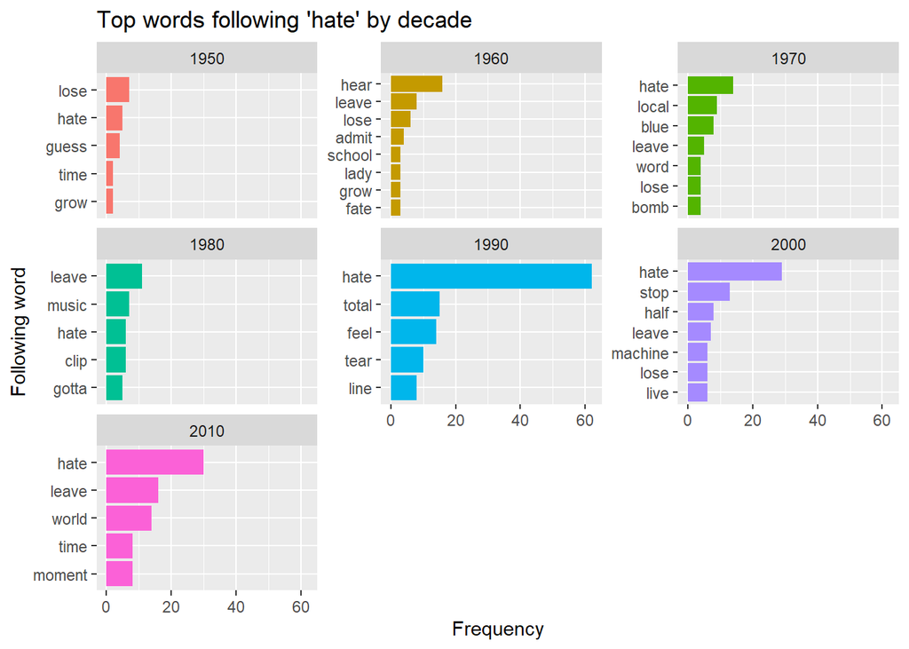

```r
bigrams_filtered %>%
  filter(word1 == "hate") %>%
  count(decade, word2, sort = TRUE) %>%
  group_by(decade) %>%
  slice_max(order_by = n, n = 5) %>%
  ggplot(aes(x = reorder_within(word2, n, decade), y = n, fill = factor(decade))) +
  geom_col(show.legend = FALSE) +
  facet_wrap(~decade, scales = "free_y") +
  scale_x_reordered() +
  coord_flip() +
  labs(
    title = "Top words following 'hate' by decade",
    x = "Following word",
    y = "Frequency"
  )
```

The conditional analysis for the word hate strongly reiterates our previous findings. In the 1950s and 60s, “**hate**” is mostly followed by personal or emotional words like “**lose**,” “**guess**,” or “**hear**”, suggesting internal or relational struggles. Notably, “**school**” appears in the 1960s. By the 1970s and 80s, themes broaden slightly, with words like “**bomb**” and “**music**”, hinting at more societal or cultural references.

## Double negation

A key limitation we encountered during our analysis relates to the treatment of negation. For example, while the word “love” is generally classified as positive, its meaning can be retracted when preceded by “not.” Hence, the analysis of bigrams with negation words is useful for this problematic.

However, as our analysis progressed we began to suspect that our dataset may have been pre-cleaned. This culminated in this section, where we specifically are unable to find any trace of common negation words such as “no,” “never,” “not,” or “without” in any of the lyrics. This absence strongly suggests that the dataset’s publishers removed stopwords (including negations) prior to publication, which limits our ability to examine how these negations affect sentiment and meaning in context. Sadly, we were not aware of this until this point, as the published did not disclose this information in their dataset description.

```r
# :(
df %>%
  filter(str_detect(
    str_to_lower(lyrics),
    "\\bnever\\b|\\bnot\\b|\\bno\\b|\\bwithout\\b"
  ))
```

```
## # A tibble: 0 × 32
## # ℹ 32 variables: ...1 <dbl>, artist_name <chr>, track_name <chr>,
## #   release_date <dbl>, genre <chr>, lyrics <chr>, len <dbl>, dating <dbl>,
## #   violence <dbl>, world/life <dbl>, night/time <dbl>,
## #   shake the audience <dbl>, family/gospel <dbl>, romantic <dbl>,
## #   communication <dbl>, obscene <dbl>, music <dbl>, movement/places <dbl>,
## #   light/visual perceptions <dbl>, family/spiritual <dbl>, like/girls <dbl>,
## #   sadness <dbl>, feelings <dbl>, danceability <dbl>, loudness <dbl>, …
```

## Moods and themes

Beyond general bigram frequencies, we now narrow our focus to a set of curated phrases that reflect dominant themes in music lyrics: love and relationships, partying and escapism, violence, and social awareness. These specific bigrams were chosen due to their commonality in popular music and because they are emotionally and culturally charged. By tracking their use over time, we can observe how the focus of lyrical content has shifted across decades.

To capture these bigrams in their original form, we use the version of the dataset that retains stopwords. As we have explained, we actually do not have a list with the full lyrics’, but as we do not know exactly what dictionary has been used to remove words, we will still attempt to make the best out of it.

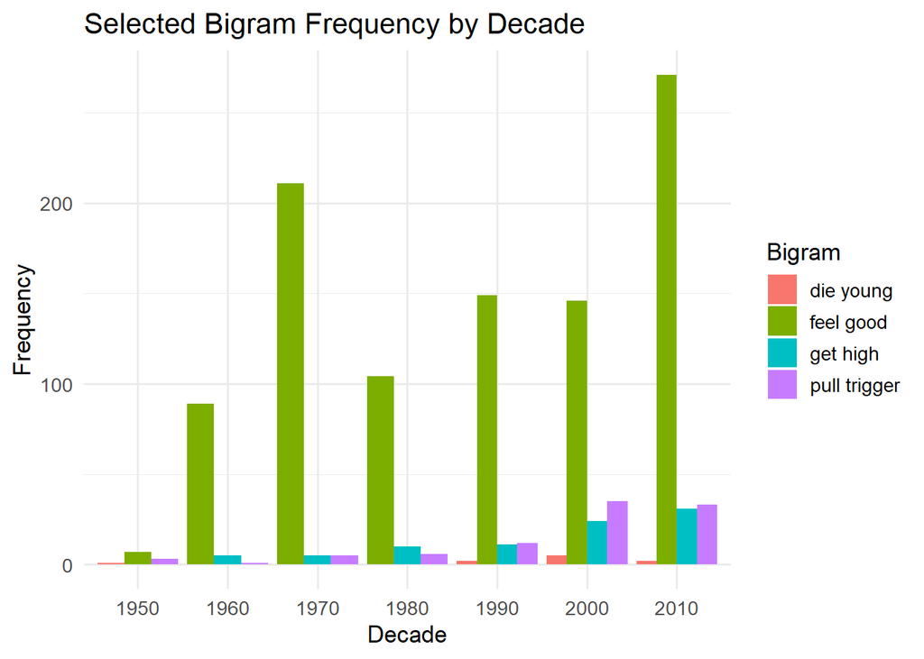

```r
bigram_counts_decade <- songs_bigrams %>%
  count(decade, bigram, sort = TRUE)

selected_bigrams <- c(
  "broken heart", "kiss me", "feel good", #love themes
  "get high", "all night", "dance all", #party themes
  "kill you", "die young", "pull trigger", #violence
  "black lives", "stand up", "wrong system") #social conscience

# Plot
bigram_counts_decade %>%
  filter(bigram %in% selected_bigrams) %>%
  ggplot(aes(x = factor(decade), y = n, fill = bigram)) +
  geom_col(position = "dodge") +
  labs(
    title = "Selected Bigram Frequency by Decade",
    x = "Decade",
    y = "Frequency",
    fill = "Bigram"
  ) +
  theme_minimal(base_size = 13)
```

### TF-IDF

After examining our hand-picked bigrams, we now shift to a more systematic approach. TF-IDF helps us identify the most distinctive bigrams in each decade based on their frequency and uniqueness. The goal is to uncover uniquely characteristics of each decade’s lyrical style, trends and themes.

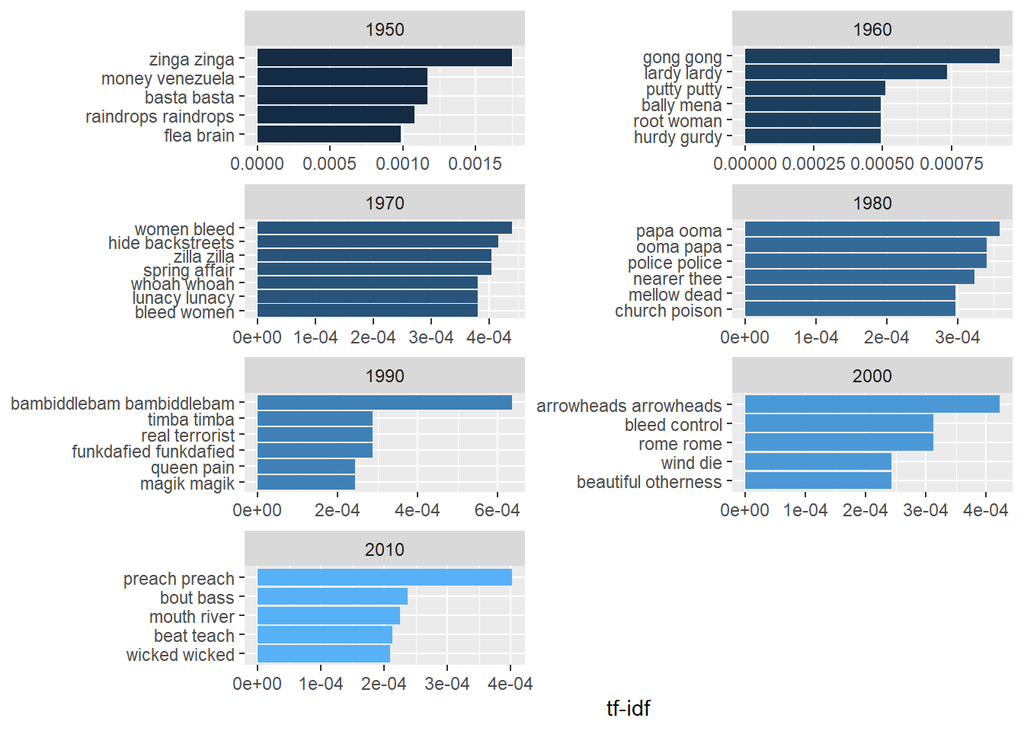

```r
bigram_tf_idf <- bigrams_united %>%
  count(decade, bigram) %>%
  bind_tf_idf(bigram, decade, n) %>%
  arrange(desc(tf_idf))

bigram_tf_idf %>%
  group_by(decade) %>%
  slice_max(tf_idf, n = 5) %>%
  ungroup() %>%
  ggplot(aes(tf_idf, fct_reorder(bigram, tf_idf), fill = decade)) +
  geom_col(show.legend = FALSE) +
  facet_wrap(~decade, ncol = 2, scales = "free") +
  labs(x = "tf-idf", y = NULL)
```

The top-scoring bigrams by decade reveal a wide variety of decade-specific expressions, many of which are stylistically unique, repetitive, or culturally embedded. In the 1950s and 60s, we observe a prevalence of nonsensical, playful, or rhythmic phrases like “**zinga** **zinga**”, “**putty** **putty**”, and “**gong** **gong**”.

By the 1970s and 80s, the most distinctive bigrams begin to take a darker turn. Phrases like “**women** **bleed**”, “**church** **poison**”, and “**mellow** **dead**” suggest an increasing willingness to explore themes of violence, institutional distrust, and existential reflection. This shift likely mirrors both changing musical genres and broader societal transformations during these decades.

From the 1990s to the 2010s, the vocabulary becomes more politically and emotionally charged. Bigram standouts such as “**real** **terrorist**”, “**bleed** **control**”, “**wicked** **wicked**”, and “**preach** **preach**” point to lyrics that engage directly with identity, power, and social critique. Some phrases (like “**bout** **bass**”) also reflect the growing influence of hip-hop and electronic genres, where rhythm, slang, and cultural reference play central roles.

The diversity of top bigrams across decades highlights how lyrics evolve not just in vocabulary, but in tone, themes, and cultural references

## Correlating

Building on our exploration of bi-grams, we wanted to further investigate how words are used together in lyrics—not only as adjacent phrases, but also in terms of broader associative patterns across entire songs. These approaches help us see not just what is said, but how ideas are built and connected throughout a song.

To begin, we used the pairwise_count() function from the widyr package to compute how often two words appear together within the same song. This allows us to move beyond adjacent word pairs and capture thematic links that might not be sequential but still co-exist within the lyrical narrative:

```r
library(widyr)

word_pairs <- lyrics_words  |>
  pairwise_count(word, song_id, sort = TRUE)
```

However, since our analysis is focused on change over time, we wanted to examine how these word relationships vary by decade. We grouped the lyrics by decade and applied the same co-occurrence method to each group:

```r
word_pairs_by_decade <- lyrics_words |>
  group_by(decade) |>
  group_split() |>
  map_df(~pairwise_count(.x, word, song_id, sort = TRUE) |>
           mutate(decade = unique(.x$decade)))

word_pairs_by_decade
```

```
## # A tibble: 28,626,376 × 4
##    item1 item2     n decade
##    <chr> <chr> <dbl>  <dbl>
##  1 heart break   116   1950
##  2 break heart   116   1950
##  3 heart time    113   1950
##  4 time  heart   113   1950
##  5 kiss  heart   105   1950
##  6 heart kiss    105   1950
##  7 leave heart   104   1950
##  8 heart leave   104   1950
##  9 dream heart   100   1950
## 10 eye   heart   100   1950
## # ℹ 28,626,366 more rows
```

This gave us a decade-by-decade view of which word pairs were most commonly used together. We filtered the results to include only pairs that appeared at least ten times and selected the top 20 for each decade. These were visualised in a faceted bar chart, highlighting the most prominent co-occurring word combinations and their evolution:

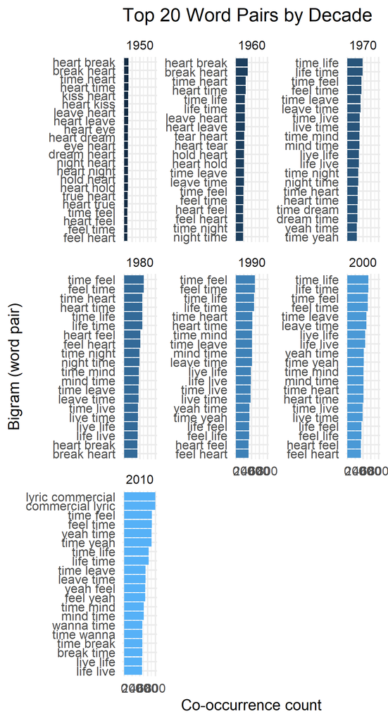

```r
top_bigrams <- word_pairs_by_decade |>
  filter(n >= 10) |>
  group_by(decade) |>
  slice_max(order_by = n, n = 20) |>
  ungroup() |>
  mutate(bigram = paste(item1, item2))


top_bigrams <- top_bigrams |>
  group_by(decade) |>
  mutate(bigram = reorder_within(bigram, n, decade)) |>
  ungroup()


ggplot(top_bigrams, aes(bigram, n, fill = decade)) +
  geom_col(show.legend = FALSE) +
  scale_x_reordered() +
  coord_flip() +
  facet_wrap(~decade, scales = "free_y") +
  theme_minimal(base_size = 20) +
  labs(
    title = "Top 20 Word Pairs by Decade",
    x = "Bigram (word pair)",
    y = "Co-occurrence count"
  )
```

This visualization reveals several interesting patterns. In the 1950s and 1960s, bigrams revolving around the word “**heart**” — such as “**heart break**” and “**kiss heart**” — dominate, reflecting the lyrical focus on romantic and emotional themes. As we move into the 1970s and 1980s, we see a shift toward introspection and existential themes, with frequent bigrams like “**time feel**” and “**live life**”. These expressions suggest a broader reflection on life, emotions, and personal experiences.

In the 2010s, the nature of lyrical expression seems to evolve significantly. The most common bigrams include phrases like “**lyric commercial**” and “**wanna time**”, indicating not only the rise of meta-lyrical content — lyrics referencing lyrics themselves — but also more colloquial, conversational phrasing. This change could be attributed to the influence of commercial pop culture, hip-hop, and the increasing informality in language use.

While co-occurrence reveals which word pairs are frequent, it does not necessarily indicate a meaningful or strong connection between them. To go one step further, we computed pairwise correlations using pairwise_cor(), which measures how often two words appear in the same songs relative to their individual frequencies. We calculated word correlations based on shared song IDs, filtering for words that appeared at least 20 times to ensure reliability:

```r
word_cors <- lyrics_words %>%
  group_by(word) %>%
  filter(n() >= 20) %>%
  pairwise_cor(word, song_id, sort = TRUE)

word_cors
```

```
## # A tibble: 36,030,006 × 3
##    item1    item2    correlation
##    <chr>    <chr>          <dbl>
##  1 oblada   obladi             1
##  2 obladi   oblada             1
##  3 mymyy    mamy               1
##  4 mamy     mymyy              1
##  5 eksen    vuke               1
##  6 vuke     eksen              1
##  7 dibidyda beepbap            1
##  8 beepbap  dibidyda           1
##  9 shuby    ketchy             1
## 10 ketchy   shuby              1
## # ℹ 36,029,996 more rows
```

We then visualized strong correlations (greater than 0.4) using a correlation network:

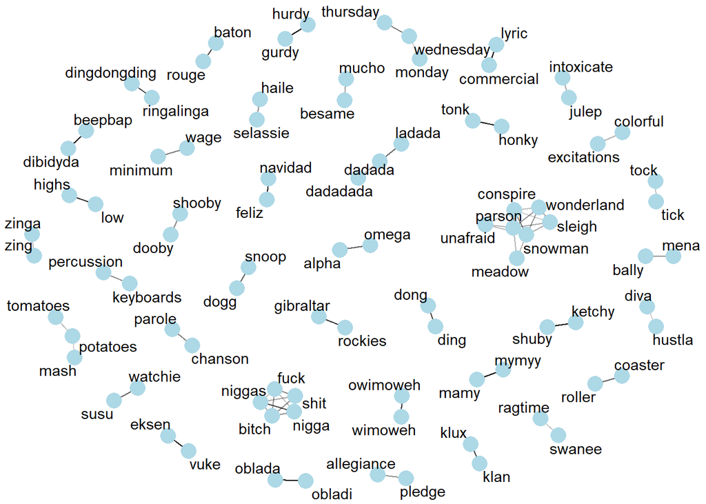

```r
set.seed(2016)

word_cors |>
  filter(correlation > 0.4) |>
  graph_from_data_frame() |>
  ggraph(layout = "fr") +
  geom_edge_link(aes(edge_alpha = correlation), show.legend = FALSE) +
  geom_node_point(color = "lightblue", size = 5) +
  geom_node_text(aes(label = name), repel = TRUE) +
  theme_void()
```

This network plot reveals clusters of words that are semantically or thematically related. For instance, we observe nodes of emotional expressions, genre-specific terms, and even playful or non-standard phonetic sounds like “dingdongding” or “shooby,” likely linked to jazz, soul, or novelty songs.

Then, to maintain our focus on temporal variation, we repeated the correlation analysis by decade. We grouped the lyrics accordingly and computed the correlations for each group separately:

```r
word_cors_by_decade <- lyrics_words |>
  group_by(decade) |>
  group_split() |>
  map_df(~ .x |>
           group_by(word) |>
           filter(n() >= 20) |>
           pairwise_cor(word, song_id, sort = TRUE) |>
           mutate(decade = unique(.x$decade))
  )
```

This allowed us to create separate word networks for different decades, helping us trace how word associations and thematic clusters have evolved. For example, the following graph illustrates the strongest correlations in the lyrics of the 2010s:

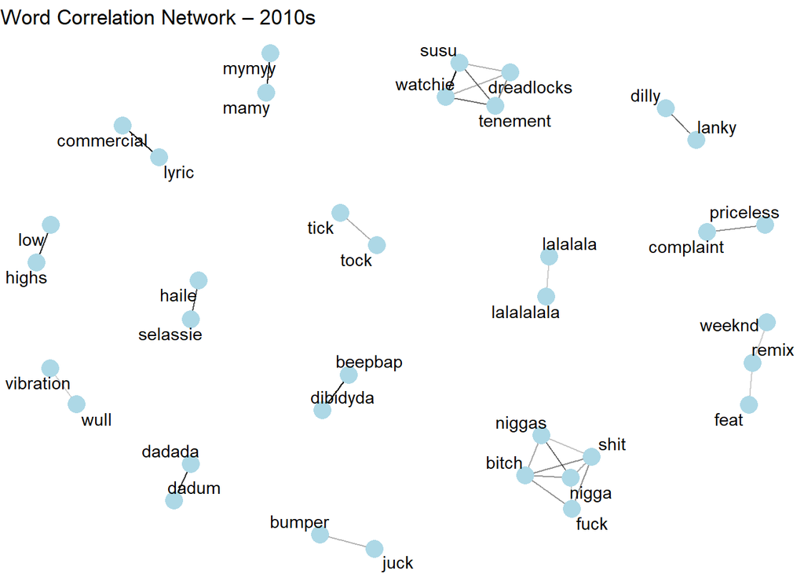

```r
word_cors_by_decade |>
  filter(decade == 2010, correlation > 0.4) |>
  graph_from_data_frame() |>
  ggraph(layout = "fr") +
  geom_edge_link(aes(edge_alpha = correlation), show.legend = FALSE) +
  geom_node_point(color = "lightblue", size = 5) +
  geom_node_text(aes(label = name), repel = TRUE) +
  theme_void() +
  ggtitle("Word Correlation Network – 2010s")
```

In contrast, this is the same graph for the 1950s:

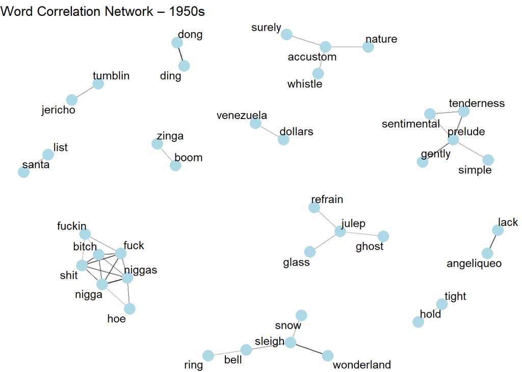

```r
word_cors_by_decade |>
  filter(decade == 1950, correlation > 0.4) |>
  graph_from_data_frame() |>
  ggraph(layout = "fr") +
  geom_edge_link(aes(edge_alpha = correlation), show.legend = FALSE) +
  geom_node_point(color = "lightblue", size = 5) +
  geom_node_text(aes(label = name), repel = TRUE) +
  theme_void() +
  ggtitle("Word Correlation Network – 1950s")
```

On one hand, the network for the 2010s reveals several distinct and tightly knit clusters, reflecting a noticeable shift toward more explicit and conversational language. Words such as “**fuck**”, “**shit**”, “**bitch**” and “**nigga**” form a densely connected group, indicating the strong presence of profane and direct expressions. Additionally, terms like “**remix**”, “**feat**” and “**weeknd**” highlight a more self-aware and commercial dimension of music in this decade, where artists frequently reference the music industry, collaboration, and celebrity culture within their lyrics.

Alongside these clusters of explicit language and cultural references, there are smaller groupings of non-lexical vocalizations such as “**lalalala**” or “**mymy**” pointing to a performative use of sound and rhythm beyond semantic meaning.

On the other hand, the 1950s network shows a more cohesive and thematically focused structure. Prominent clusters include words related to sentimentality and romance, such as “**tenderness**”, “**simple**” and “**sentimental**”, which aligns with the emotional tone prevalent in mid-century ballads. Playful, sound-based terms like “**ding**”, “**dong**” and “**whistle**” also appear, reflecting an interest in phonetic play and melodic embellishments typical of early rock ‘n’ roll. Interestingly, words like “**fuck**”, “**bitch**” or “**nigga**” do appear in the 1950s network, possibly hinting at the presence of fringe or subversive lyrical content even during a more culturally conservative era.

# Topic modeling

To uncover broader thematic patterns in song lyrics, we turned to topic modelling, a powerful text mining technique that enables us to detect underlying semantic structures in large collections of documents. It provides a more abstract, yet insightful, lens through which to view the evolution of meaning and content over time.

Specifically, we employed Latent Dirichlet Allocation (LDA), a probabilistic model that assumes each document (in our case, a song or group of songs) is a mixture of multiple topics, and that each topic is itself a distribution over words.

Our first step was to prepare the data. We began by tokenizing the lyrics and removing stopwords to focus only on the meaningful terms. Then, we counted the occurrences of each word per decade, giving us a term frequency distribution that we used to build a Document-Term Matrix (DTM), where each decade represented a document. We chose to treat each decade as a single document in order to extract high-level thematic trends over time, rather than focusing on the granularity of individual songs.

```r
# Count word frequencies per decade, removing stopwords
word_counts <- df %>%
  unnest_tokens(word, lyrics) %>%
  anti_join(stop_words) %>%
  count(decade, word, sort = TRUE)
# Create DTM using each decade as one document
dtm <- word_counts %>%
  cast_dtm(decade, word, n)
```

We then applied Latent Dirichlet Allocation (LDA).

## Topics by individual decades (k = 7)

Our first approach was to set k (the number of topics) of the LDA to 7, as many as there are decades. This approach potentially smooths over within-decade variation. However, we hoped that it would provide an interpretable basis for comparing topic prevalence across time.

We are going to skip the code explanation to go directly into showing the results, and see why an alternative path is a better option.

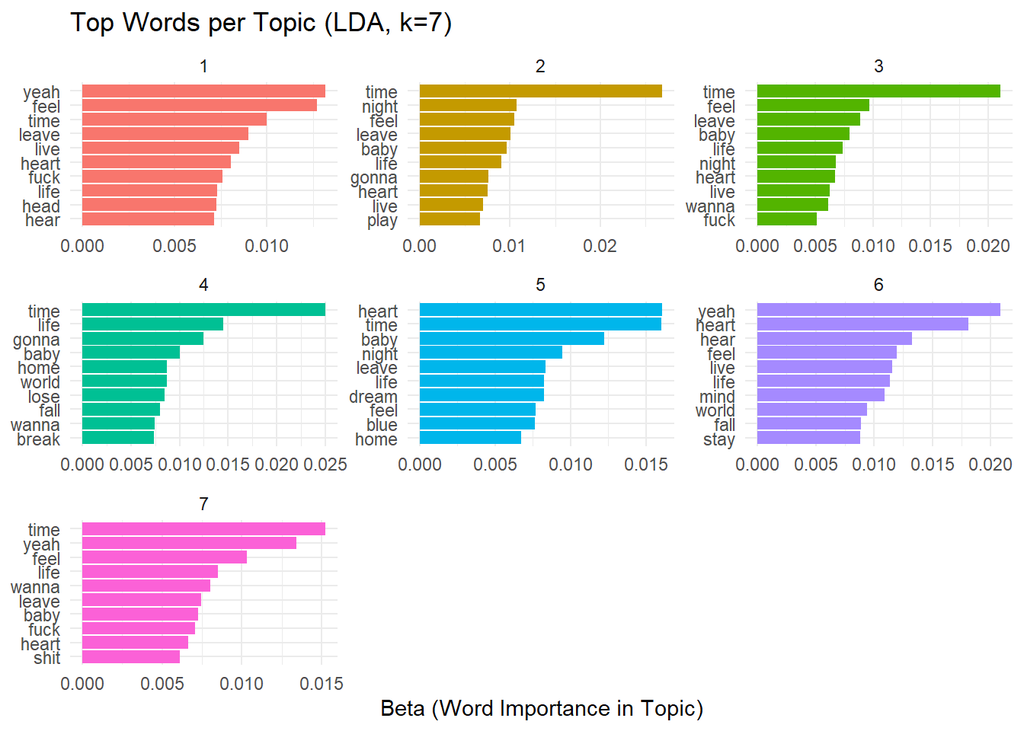

```r
# LDA topic model with 7 topics (k = 7)
lda_model <- LDA(dtm, k = 7, control = list(seed = 1234))

# Beta table: word-topic probabilities
lda_topics <- tidy(lda_model)

# Top 10 words per topic based on beta values
top_terms <- lda_topics %>%
  group_by(topic) %>%
  slice_max(beta, n = 10) %>%
  ungroup() %>%
  arrange(topic, -beta)

# Plot
top_terms %>%
  mutate(term = reorder_within(term, beta, topic)) %>%
  ggplot(aes(beta, term, fill = as.factor(topic))) +
  geom_col(show.legend = FALSE) +
  facet_wrap(~ topic, scales = "free") +
  scale_y_reordered() +
  labs(
    title = "Top Words per Topic (LDA, k=7)",
    x = "Beta (Word Importance in Topic)",
    y = NULL
  ) +
  theme_minimal()
```

While setting k = 7 offers an appealing symmetry with the number of decades in our dataset, the resulting topics show substantial lexical overlap. Words like “**time**,” “**feel**,” **life**,” “**baby**,” “**heart**,” and “**leave**” appear across nearly all topics. This suggests that the model is capturing the most frequent and general emotional vocabulary in the corpus, but struggling to separate them into truly distinct semantic clusters.

While some subtle differences emerge, they are relatively small. For example, Topic 4 includes slightly more references to “**home**,” “**lose**,” and “**break**,” while Topic 6 has words like “**mind**,” “**stay**,” and “**fall**.” Several topics seem dominated by interchangeable personal or relational terms, often varying only slightly in tone or word form.

Overall, the topics appear redundant and repetitive, likely because high-frequency words are spread evenly across decades rather than being unique to any single period. Hence, we chose to abandon the idea of mapping each topic to a specific decade.

## Topics by groupings of decades

Therefore, given the lexical overlap we observed in the seven-topic model, we adjusted our approach. After testing various configurations, determined that two topics (k = 2) provided the most interpretable and distinct division of themes across the corpus. Rather than forcing each decade into its own cluster, we now allow the model to explore a smaller number of broader themes that may better capture meaningful contrasts in lyrical content within the decades.

We begin again by applying LDA to our DTM.

```r
# LDA topic model with 2 topics (k = 2) for interpretability
lda_model <- LDA(dtm, k = 2, control = list(seed = 1234))
```

Next, we extracted the beta values from the model, which represent the probability of each word being associated with each topic. This allowed us to identify the top terms most representative of each topic:

```r
# Beta table: word-topic probabilities
lda_topics <- tidy(lda_model)

# Top 10 words per topic based on beta values
top_terms <- lda_topics %>%
  group_by(topic) %>%
  slice_max(beta, n = 10) %>%
  ungroup() %>%
  arrange(topic, -beta)

top_terms
```

```
## # A tibble: 20 × 3
##    topic term     beta
##    <int> <chr>   <dbl>
##  1     1 time  0.0210
##  2     1 yeah  0.0177
##  3     1 live  0.0125
##  4     1 baby  0.0114
##  5     1 heart 0.00973
##  6     1 leave 0.00920
##  7     1 feel  0.00896
##  8     1 mind  0.00810
##  9     1 gonna 0.00777
## 10     1 world 0.00723
## 11     2 night 0.0129
## 12     2 life  0.0126
## 13     2 feel  0.0114
## 14     2 heart 0.0104
## 15     2 time  0.00944
## 16     2 break 0.00869
## 17     2 hold  0.00869
## 18     2 hear  0.00814
## 19     2 play  0.00717
## 20     2 money 0.00685
```

We visualized these top terms to gain an intuitive understanding of each topic’s content:

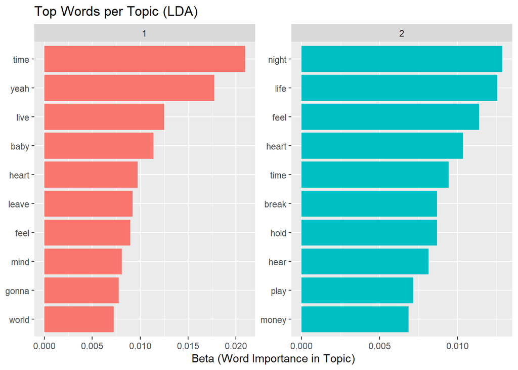

```r
# Plot
top_terms %>%
  mutate(term = reorder_within(term, beta, topic)) %>%
  ggplot(aes(beta, term, fill = as.factor(topic))) +
  geom_col(show.legend = FALSE) +
  facet_wrap(~ topic, scales = "free") +
  scale_y_reordered() +
  labs(
    title = "Top Words per Topic (LDA)",
    x = "Beta (Word Importance in Topic)",
    y = NULL
  )
```

Topic 1 is dominated by words such as **time**, **yeah**, **live**, **baby**, **heart**, and **feel**, suggesting a focus on personal emotion, relationships, and introspection. This cluster appears to capture the intimate and expressive side of songwriting, maybe reflecting themes of love, inner life, and emotional experience. The presence of colloquial markers like **yeah** and **gonna** further hints at a conversational and informal tone in the lyrics grouped under this theme.

Topic 2, on the other hand, centers around words like **night**, **life**, **break**, **play**, **money**, and **hold**. The inclusion of terms like night and play suggests a connection to nightlife or entertainment, while money and break might indicate ambition, success, or personal struggle. Compared to Topic 1, this cluster seems more outward-facing and grounded in external events or settings.

Overall, the LDA results offer a high-level view of the thematic duality in the lyrics: one topic capturing the emotional and relational aspects of songs, and the other reflecting experiential, material, and performative dimensions.

However, analyzing topic content alone is not enough, we also are looking to understand how these topics varied in prominence over time. To do that, we extracted the gamma values from the model, which indicate how much each topic contributes to each document. We linked each document back to its release decade to track changes in topic prevalence:

```r
# Gamma matrix: topic distribution per document
gamma_df <- tidy(lda_model, matrix = "gamma")

# The 'document' column already holds decade as a string => conversion to numeric
gamma_df <- gamma_df %>%
  mutate(decade = as.numeric(document))
```

We then calculated the average topic proportion for each decade:

```r
# Average topic share per decade
topic_by_decade <- gamma_df %>%
  group_by(decade, topic) %>%
  summarise(mean_gamma = mean(gamma), .groups = "drop")

topic_by_decade
```

```
## # A tibble: 14 × 3
##    decade topic mean_gamma
##     <dbl> <int>      <dbl>
##  1   1950     1      0.470
##  2   1950     2      0.530
##  3   1960     1      0.512
##  4   1960     2      0.488
##  5   1970     1      0.535
##  6   1970     2      0.465
##  7   1980     1      0.523
##  8   1980     2      0.477
##  9   1990     1      0.558
## 10   1990     2      0.442
## 11   2000     1      0.566
## 12   2000     2      0.434
## 13   2010     1      0.601
## 14   2010     2      0.399
```

And plotted the temporal evolution of each topic’s prominence:

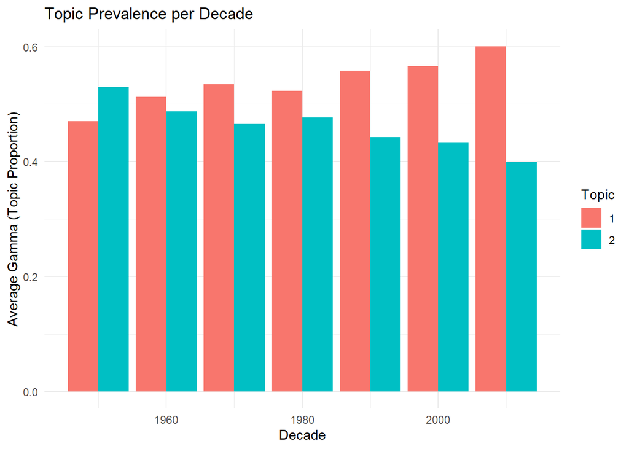

```r
# Plot
ggplot(topic_by_decade, aes(x = decade, y = mean_gamma, fill = factor(topic))) +
  geom_col(position = "dodge") +
  labs(
    title = "Topic Prevalence per Decade",
    x = "Decade",
    y = "Average Gamma (Topic Proportion)",
    fill = "Topic"
  ) +
  theme_minimal()
```

This plot shows how the two topics identified by the LDA model vary in prevalence across decades, based on the average gamma values.

Taken together, these results suggest a shift in lyrical focus across decades: from a more outward-facing, situational or performative style (Topic 2) in the earlier decades, toward a more inward-looking, emotionally charged, and conversational style (Topic 1) in more recent decades. This aligns with broader trends in music and pop culture, where personal storytelling and emotional authenticity have become increasingly central. erhaps this shift also helps explain the growing presence of emotions like anger, sadness, and fear in lyrics, as artists not only express love but also explore more diverse and vulnerable aspects of the human experience.

# Conclusion

The evolution of language, particularly the rise of more aggressive or explicit terms, mirrored broader cultural and stylistic changes, such as the emergence of hip-hop and alternative genres. Bigrams and word networks further highlighted this shift, contrasting the romantic simplicity of earlier lyrics with the commercialism, social critique, and raw expression of modern music.

Sentiment analysis revealed a steady shift from the optimism of early decades to a growing presence of negative and emotionally intense language. While **joy** remained a lyrical constant, emotions such as **sadness**, **fear**, and **anger** became increasingly dominant, particularly in recent decades. This growing emotional complexity and diversity reflects a broader move toward introspection, vulnerability, and rawness in modern songwriting.

Topic modelling further deepened this picture by identifying two main thematic clusters across the corpus: one centred on emotion, intimacy, and personal experience, and another on external action, entertainment, and material themes. Over time, the prevalence of the inward-looking topic grew, suggesting that songs have increasingly become vehicles for personal storytelling and emotional self-expression. This shift may also help explain the rise in darker emotional tones—as artists move beyond traditional themes like love to engage more honestly with pain, conflict, and identity.

In conclusion, our analyses show that lyrics have not only changed, they seem to have matured. They are longer, more emotionally diverse, more thematically nuanced, and more reflective of both personal and societal complexity. Music, as a cultural artifact, continues to echo the times—and those echoes have grown louder, more varied, and seemingly, more human.

# Sources

Moura, Luan; Fontelles, Emanuel; Sampaio, Vinicius; França, Mardônio (2020), “Music Dataset: Lyrics and Metadata from 1950 to 2019”, Mendeley Data, V3, doi: 10.17632/3t9vbwxgr5.3

[^1]: [Wikipedia](https://en.wikipedia.org/wiki/1970s_in_music) has great articles on the popular music throughout the decades, such as for the 1970s: “In North America, Europe, and Oceania, the decade saw the rise of disco, which then went on to become one of the biggest genres of the decade, especially in the mid-to-late 1970s. In Europe, a variant known as Euro disco rose in popularity towards the end of the 1970s. Aside from disco, funk, soul, R&B, smooth jazz, and jazz fusion remained popular throughout the decade. Rock music played an important part in the Western musical scene, with punk rock thriving throughout the mid to late 1970s.”
[^2]: [Wikipedia](https://en.wikipedia.org/wiki/2000s_in_music): “In 2004, the Billboard Year-End Hot 100 had 15 of its top 25 singles as contemporary R&B.”
[^3]: If time is available, we highly recomend looking at lyrics with the word “crab” in it. They are incredible. Do not ponder how we stumbled across it.
[^4]: https://genius.com/The-impressions-im-the-one-who-loves-you-lyrics